# Some Simple SPOOKY Data Analysis

Huijun Cui

January 31, 2018

I. Prerequisite 1. Setup the libraries

```r
packages.used <- c("ggplot2", "dplyr", "tibble", "tidyr",  "stringr", "tidytext", "topicmodels", "wordcloud", "ggridges","igraph","tweenr","ggraph","scales")

# check packages that need to be installed.
packages.needed <- setdiff(packages.used, intersect(installed.packages()[,1], packages.used))

# install additional packages
if(length(packages.needed) > 0) {
  install.packages(packages.needed, dependencies = TRUE, repos = 'http://cran.us.r-project.org')
}

library(ggplot2)
library(dplyr)
library(tibble)
library(tidyr)
library(stringr)
library(tidytext)
#install.packages("topicmodels")
library(topicmodels)
library(wordcloud)
library(ggridges)
#install.packages("igraph")
library(igraph)
#install.packages("tweenr")
#library(tweenr)
#install.packages("ggraph")
library(ggraph)
library(scales)

source("../libs/multiplot.R")
```

2. Read in the data

```r
spk <- read.csv('../data/spooky.csv', as.is = TRUE)
```

3. An overview of the data structure and content

```r
head(spk)
```

```
##        id
## 1 id26305
## 2 id17569
## 3 id11008
## 4 id27763
## 5 id12958
## 6 id22965
##                                                                                                                                                                                                                                                                                                          …
## 1                                                                                                                                                                                                                                              This process, however, afforded me no means of ascertainin…
## 2                                                                                                                                                                                                                                                                                                        …
## 3                                                                                                                                                                                                                                                                             In his left hand was a gold…
## 4                                                                                                                                                                                                                                                                       How lovely is spring As we looked…
## 5                                                                                                                                                                                                                                                                                                       F…
## 6 A youth passed in solitude, my best years spent under your gentle and feminine fosterage, has so refined the groundwork of my character that I cannot overcome an intense distaste to the usual brutality exercised on board ship: I have never believed it to be necessary, and when I heard of a mari…
##   author
## 1    EAP
## 2    HPL
## 3    EAP
## 4    MWS
## 5    HPL
## 6    MWS
```

```r
summary(spk)
```

```
##       id                text              author
##  Length:19579       Length:19579       Length:19579
##  Class :character   Class :character   Class :character
##  Mode  :character   Mode  :character   Mode  :character
```

Each row of the dataset contains a unique ID, a single sentence text excerpt, and an abbreviated author name. `HPL` is Lovecraft, `MWS` is Shelly, and `EAP` is Poe.

```r
sum(is.na(spk))
```

```
## [1] 0
```

```r
spk$author <- as.factor(spk$author)
```

Thus, there are no missing values. And the author name is transformed to be a factor variable.

2. Data Cleaning

The `unnest_tokens()` function to drop all punctuation and transform all words into lower case. At least for now, the punctuation isn’t really important to our analysis – we want to study the words. In addition, `tidytext` contains a dictionary of stop words, like “and” or “next”, that we will get rid of for our analysis, the idea being that the non-common words (…maybe the SPOOKY words) that the authors use will be more interesting.

```r
#library(janeaustenr)
library(dplyr)
library(stringr)

spk_byauthor <- spk %>%
  group_by(author) %>%
  mutate(linenumber = row_number()) %>%
  ungroup()
spkline <- spk %>%
  mutate(line = row_number())

spk_wrd <- unnest_tokens(spk_byauthor, word, text)
spk_wrdn <- unnest_tokens(spkline, word, text) %>%
  group_by(line)%>%
  mutate(wordorder = row_number())%>%
  ungroup
spk_wrd <- spk_wrd %>% anti_join(stop_words)
```

3. Data analysis
1. Stop word analysis

```r
#library(janeaustenr)
library(dplyr)
library(stringr)

spk_byauthor <- spk %>%
  group_by(author) %>%
  mutate(linenumber = row_number()) %>%
  ungroup()

spk_wrd <- unnest_tokens(spk_byauthor, word, text)
spk_stp <- unnest_tokens(spk_byauthor, word, text) %>% semi_join(stop_words)
author_words <- count(group_by(spk_stp, word, author))

all_words    <- rename(count(group_by(spk_stp, word)), all = n)
author_words <- left_join(author_words, all_words, by = "word")
author_words <- arrange(author_words, desc(all))
author_words <- ungroup(head(author_words, 81))
author_words
```

```
## # A tibble: 81 x 4
##    word  author     n   all
##    <chr> <fct>  <int> <int>
##  1 the   EAP    14993 35585
##  2 the   HPL    10933 35585
##  3 the   MWS     9659 35585
##  4 of    EAP     8972 20955
##  5 of    HPL     5846 20955
##  6 of    MWS     6137 20955
##  7 and   EAP     5735 17956
##  8 and   HPL     6098 17956
##  9 and   MWS     6123 17956
## 10 to    EAP     4765 12842
## # ... with 71 more rows
```

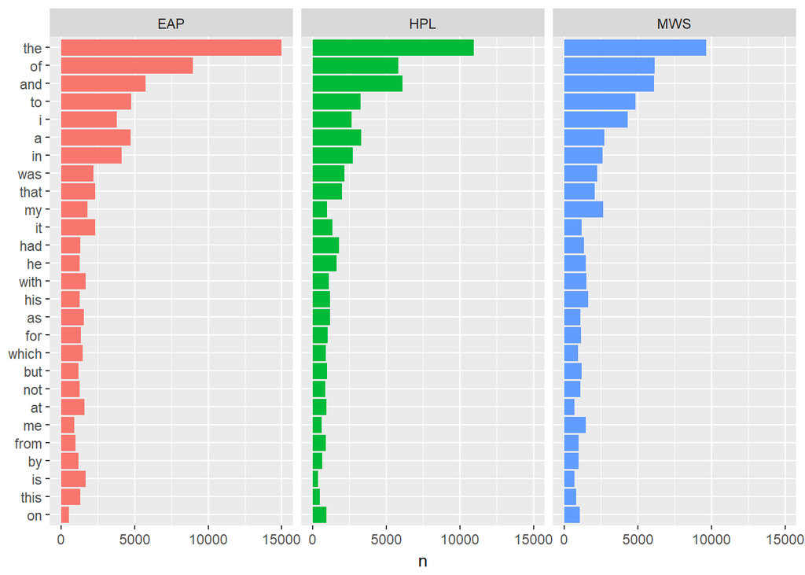

```r
#png("../figs/stopword_frequency.png")
ggplot(author_words) +
  geom_col(aes(reorder(word, all, FUN = min), n, fill = author)) +
  xlab(NULL) +
  coord_flip() +
  facet_wrap(~ author) +
  theme(legend.position = "none")
```

```r
summary(spk_wrd)
```

```
##       id            author         linenumber       word
##  Length:522984      EAP:200965   Min.   :   1   Length:522984
##  Class :character   HPL:156319   1st Qu.:1630   Class :character
##  Mode  :character   MWS:165700   Median :3239   Mode  :character
##                                  Mean   :3322
##                                  3rd Qu.:4886
##                                  Max.   :7900
```

```r
summary(spk_byauthor)
```

```
##       id                text           author       linenumber
##  Length:19579       Length:19579       EAP:7900   Min.   :   1
##  Class :character   Class :character   HPL:5635   1st Qu.:1632
##  Mode  :character   Mode  :character   MWS:6044   Median :3264
##                                                   Mean   :3338
##                                                   3rd Qu.:4895
##                                                   Max.   :7900
```

The picture shows the habits of the three writers when they use stop words, and the second table provides the precise values of frequency of stop words. In the table, n is the stop word frequency of each author, while all refers to the frequency of all three authors. From these materials, we can find generally authors have similar tendency in stop word using, but typically EAP like to utilize stop words more than other two authors(especially in the example of word ‘the’). However, the summary also shows that there are more sentences and words from EAP in the dataset, therefore the distribution may also result from this quantitative superiority.

2. First word analysis

```r
spkline <- spk %>%
  mutate(line = row_number())

spk_wrdn <- unnest_tokens(spkline, word, text) %>%
  group_by(line)%>%
  mutate(wordorder = row_number())%>%
  ungroup

first_wrd <- filter(spk_wrdn, wordorder == 1)
first_wrd
```

```
## # A tibble: 19,579 x 5
##    id      author  line word    wordorder
##    <chr>   <fct>  <int> <chr>       <int>
##  1 id26305 EAP        1 this            1
##  2 id17569 HPL        2 it              1
##  3 id11008 EAP        3 in              1
##  4 id27763 MWS        4 how             1
##  5 id12958 HPL        5 finding         1
##  6 id22965 MWS        6 a               1
##  7 id09674 EAP        7 the             1
##  8 id13515 EAP        8 the             1
##  9 id19322 EAP        9 i               1
## 10 id00912 MWS       10 i               1
## # ... with 19,569 more rows
```

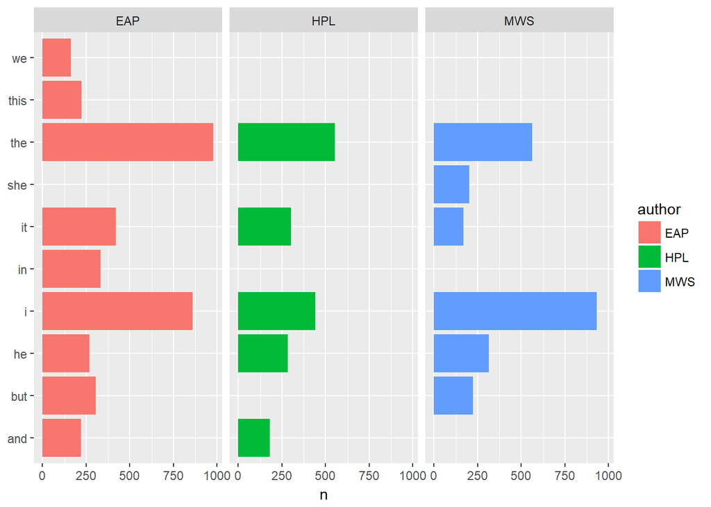

```r
#png("../figs/firstword_distribution.png")
first_wrd %>%
  group_by(author)%>%
  count(word, sort = TRUE) %>%
  head(20) %>%
  mutate(first = reorder(word, n)) %>%
  ggplot(aes(first, n, fill = author)) +
  geom_col() +
  xlab(NULL) +
  coord_flip() +
  facet_wrap(~ author)
```

The table above shows the occupation modes of the first word of each sentence, and the table describes the first word(wih the top 20 frequencies ) utilization distribution of each authors. They show that most of first words are stop words, so the word distribution also corresponds to the results in stop word analysis – the words EAP utilized as first words occupies more percentage in the most popular first word group.

3. Word frequency analysis

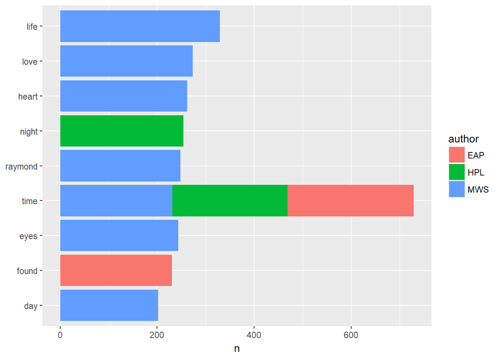

```r
library(ggplot2)

spk_wrd <- spk_wrd %>% anti_join(stop_words)
spk_count <- spk_wrd %>%
  group_by(author) %>%
  count(word, sort = TRUE) %>%
  ungroup
#png("../figs/topwords.png")
spk_count %>%
  filter(n > 200) %>%
  mutate(word = reorder(word, n)) %>%
  ggplot(aes(word, n, fill = author)) +
  geom_col() +
  xlab(NULL) +
  coord_flip()
```

```r
spk_count
```

```
## # A tibble: 40,185 x 3
##    author word        n
##    <fct>  <chr>   <int>
##  1 MWS    life      329
##  2 MWS    love      273
##  3 MWS    heart     262
##  4 EAP    time      260
##  5 HPL    night     254
##  6 MWS    raymond   248
##  7 MWS    eyes      243
##  8 HPL    time      238
##  9 MWS    time      231
## 10 EAP    found     230
## # ... with 40,175 more rows
```

These gragh and table give us the description of word analysis without consideration about stop words. From both the gragh and the table, it is obvious that MWS contributes most words (no stop word) in the dataset, though for some special cases like ‘time’, ‘night’, ‘found’ and etc, EAP and HPL dominate more. From this phenomena we can induce that MWS does not like to use stop words compared with other two authors.

```r
spk_eap <- filter(spk_wrd, author == "EAP")
spk_hpl <- filter(spk_wrd, author == "HPL")
spk_mws <- filter(spk_wrd, author == "MWS")

spk_eap %>%
  count(word, sort = TRUE)
```

```
## # A tibble: 14,868 x 2
##    word       n
##    <chr>  <int>
##  1 time     260
##  2 found    230
##  3 length   178
##  4 day      174
##  5 eyes     168
##  6 head     164
##  7 night    143
##  8 left     140
##  9 matter   139
## 10 de       133
## # ... with 14,858 more rows
```

```r
spk_hpl %>%
  count(word, sort = TRUE)
```

```
## # A tibble: 14,202 x 2
##    word        n
##    <chr>   <int>
##  1 night     254
##  2 time      238
##  3 house     188
##  4 found     186
##  5 heard     174
##  6 strange   169
##  7 street    146
##  8 told      143
##  9 door      142
## 10 day       140
## # ... with 14,192 more rows
```

```r
spk_mws %>%
  count(word, sort = TRUE)
```

```
## # A tibble: 11,115 x 2
##    word        n
##    <chr>   <int>
##  1 life      329
##  2 love      273
##  3 heart     262
##  4 raymond   248
##  5 eyes      243
##  6 time      231
##  7 day       202
##  8 death     192
##  9 father    173
## 10 mind      162
## # ... with 11,105 more rows
```

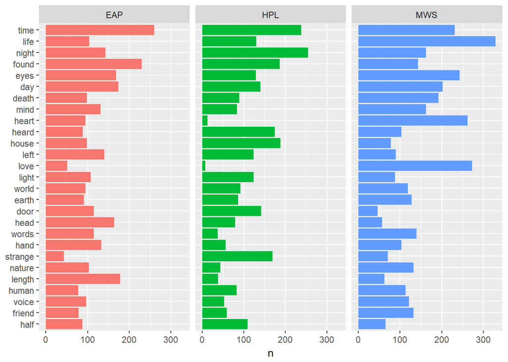

```r
# Counts number of times each author used each word.
author_words <- count(group_by(spk_wrd, word, author))

# Counts number of times each word was used.
all_words    <- rename(count(group_by(spk_wrd, word)), all = n)

author_words <- left_join(author_words, all_words, by = "word")
author_words <- arrange(author_words, desc(all))
author_words <- ungroup(head(author_words, 81))
#png("../figs/topword_distribution.png")
ggplot(author_words) +
  geom_col(aes(reorder(word, all, FUN = min), n, fill = author)) +
  xlab(NULL) +
  coord_flip() +
  facet_wrap(~ author) +
  theme(legend.position = "none")
```

This part is about the detailed word profiles of the authors. We can see the wording preference of difference writers, like MWS tends to talk about life, while HPL and EAP prefer to discuss about time, MWS loves to mention love, while the other two authors are not. The first table is the word and its frequency list of EAP, the second table is for HPL, and the third one is for MWS.

```r
# Words is a list of words, and freqs their frequencies
spk_wrd <- spk_wrd %>% anti_join(stop_words)
```

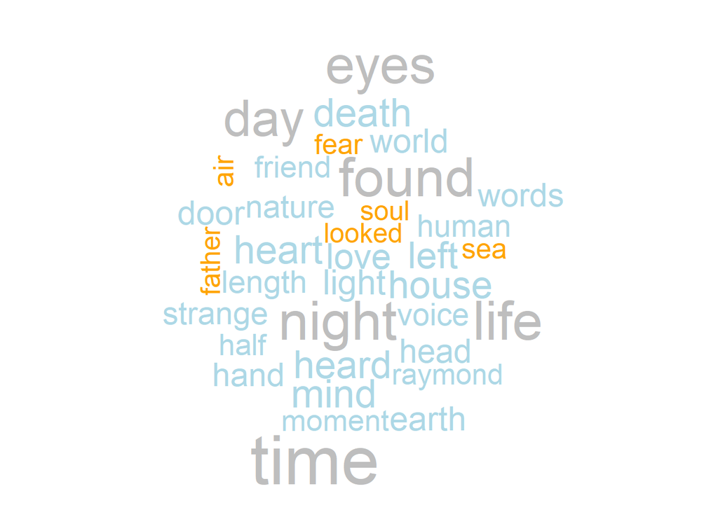

```r
wordstotal <- count(group_by(spk_wrd, word))$word
freqstotal <- count(group_by(spk_wrd, word))$n

wordseap <- count(group_by(spk_eap, word))$word
freqseap <- count(group_by(spk_eap, word))$n

wordshpl <- count(group_by(spk_hpl, word))$word
freqshpl <- count(group_by(spk_hpl, word))$n

wordsmws <- count(group_by(spk_mws, word))$word
freqsmws <- count(group_by(spk_mws, word))$n

#png("../figs/Wordcloud_all.png")
wordcloud(wordstotal, freqstotal, max.words = 35, color = c("orange", "lightblue","grey"))
```

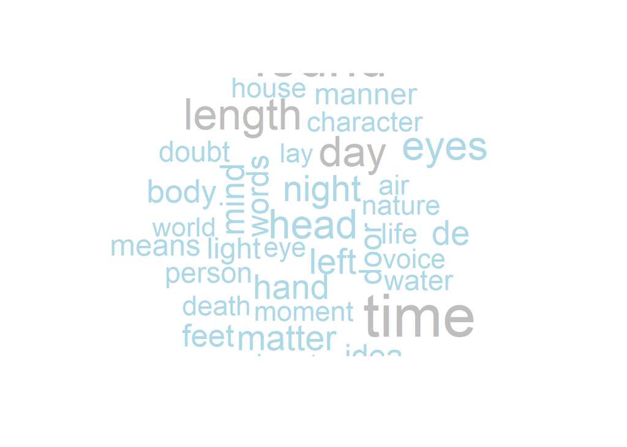

```r
#png("../figs/Wordcloud_eap.png")
wordcloud(wordseap, freqseap, max.words = 35, color = c("orange", "lightblue","grey"))
```

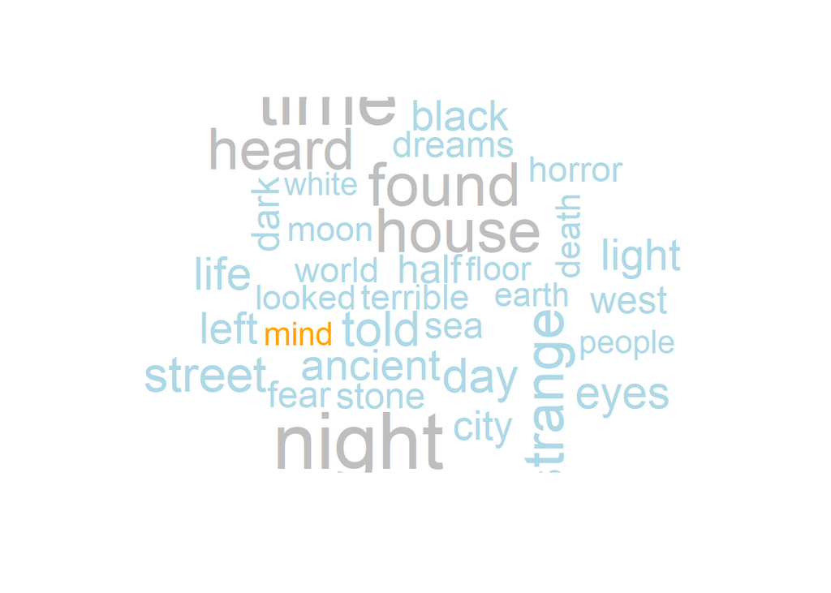

```r
#png("../figs/Wordcloud_hpl.png")
wordcloud(wordshpl, freqshpl, max.words = 35, color = c("orange", "lightblue","grey"))
```

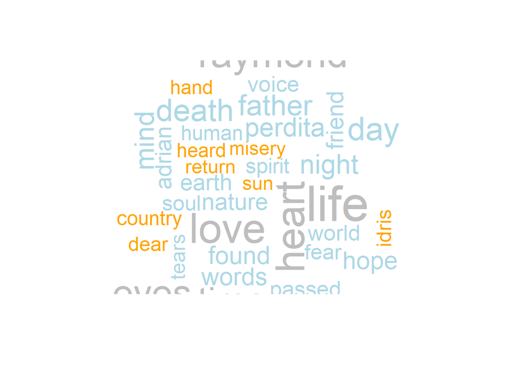

```r
#png("../figs/Wordcloud_mws.png")
wordcloud(wordsmws, freqsmws, max.words = 35, color = c("orange", "lightblue","grey"))
```

```r
#dev.off()
```

Here are the word cloud graphs, in whih the 35 most common words in the entire datset and personal dataset of each writer are plotted. It is very intuitionistic that “time”, “life”, and “night” all appear frequently.

4. Correlation analysis from data of different authoers

```r
frequency <- spk_wrd %>%
  #extract words from possible italics
  mutate(word = str_extract(word, "[a-z']+")) %>%
  count(author, word) %>%
  group_by(author) %>%
  mutate(proportion = n / sum(n)) %>%
  select(-n) %>%
  spread(author, proportion) %>%
  gather(author, proportion,'EAP':'HPL')

frequency
```

```
## # A tibble: 49,858 x 4
##    word               MWS author proportion
##    <chr>            <dbl> <chr>       <dbl>
##  1 a           NA         EAP     0.0000412
##  2 aaem        NA         EAP     0.0000137
##  3 ab          NA         EAP     0.0000137
##  4 aback       NA         EAP     0.0000274
##  5 abaft        0.0000160 EAP    NA
##  6 abandon      0.0000160 EAP     0.0000960
##  7 abandoned    0.0000800 EAP     0.000151
##  8 abandoning  NA         EAP     0.0000274
##  9 abandonment  0.0000480 EAP     0.0000274
## 10 abaout      NA         EAP    NA
## # ... with 49,848 more rows
```

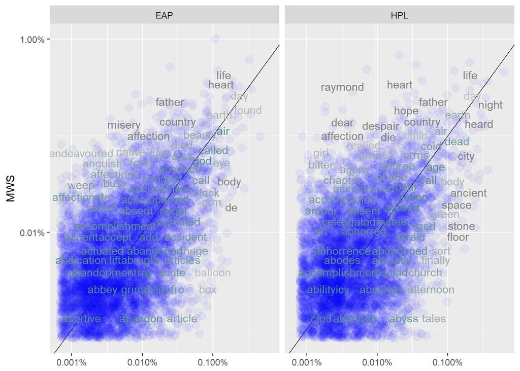

```r
library(scales)

# expect a warning about rows with missing values being removed
#png("../figs/frequencycorrelationMWS.png")
ggplot(frequency, aes(x = proportion, y = MWS, color = abs(MWS - proportion))) +
  geom_abline(color = "gray10", lty = 1) +
  geom_jitter(alpha = 0.05, color = 12, size = 3.5, width = 0.3, height = 0.3) +
  geom_text(aes(label = word), check_overlap = TRUE, vjust = 1.5) +
  scale_x_log10(labels = percent_format()) +
  scale_y_log10(labels = percent_format()) +
  scale_color_gradient(limits = c(0, 0.001), low = "darkslategray4", high = "gray75") +
  facet_wrap(~author, ncol = 2) +
  theme(legend.position="none") +
  labs(y = "MWS", x = NULL)
```

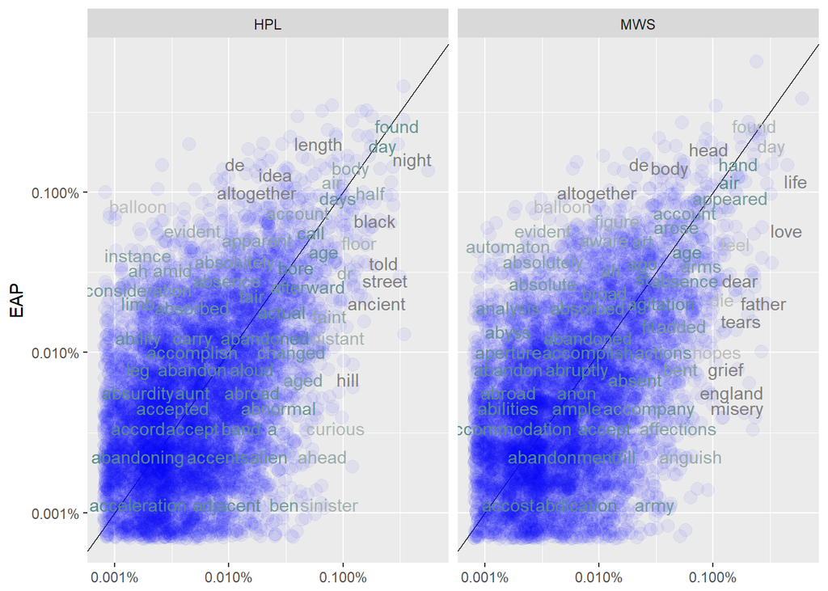

```r
frequency2 <- spk_wrd %>%
  #extract words from possible italics
  mutate(word = str_extract(word, "[a-z']+")) %>%
  count(author, word) %>%
  group_by(author) %>%
  mutate(proportion = n / sum(n)) %>%
  select(-n) %>%
  spread(author, proportion) %>%
  gather(author, proportion,'MWS':'HPL')

library(scales)
# expect a warning about rows with missing values being removed
#png("../figs/frequencycorrelationeap.png")
ggplot(frequency2, aes(x = proportion, y = EAP, color = abs(EAP - proportion))) +
  geom_abline(color = "gray10", lty = 1) +
  geom_jitter(alpha = 0.05, color = 12, size = 3.5, width = 0.3, height = 0.3) +
  geom_text(aes(label = word), check_overlap = TRUE, vjust = 1.5) +
  scale_x_log10(labels = percent_format()) +
  scale_y_log10(labels = percent_format()) +
  scale_color_gradient(limits = c(0, 0.001), low = "darkslategray4", high = "gray75") +
  facet_wrap(~author, ncol = 2) +
  theme(legend.position="none") +
  labs(y = "EAP", x = NULL)
```

```r
cor.test(data = frequency[frequency$author == "EAP",],
         ~ proportion + MWS)
```

```
##
##  Pearson's product-moment correlation
##
## data:  proportion and MWS
## t = 65.709, df = 6800, p-value < 2.2e-16
## alternative hypothesis: true correlation is not equal to 0
## 95 percent confidence interval:
##  0.6084326 0.6375106
## sample estimates:
##       cor
## 0.6231869
```

```r
cor.test(data = frequency[frequency$author == "HPL",],
         ~ proportion + MWS)
```

```
##
##  Pearson's product-moment correlation
##
## data:  proportion and MWS
## t = 53.903, df = 6167, p-value < 2.2e-16
## alternative hypothesis: true correlation is not equal to 0
## 95 percent confidence interval:
##  0.5487050 0.5826377
## sample estimates:
##      cor
## 0.565911
```

```r
cor.test(data = frequency2[frequency2$author == "HPL",],
         ~ proportion + EAP)
```

```
##
##  Pearson's product-moment correlation
##
## data:  proportion and EAP
## t = 68.623, df = 7147, p-value < 2.2e-16
## alternative hypothesis: true correlation is not equal to 0
## 95 percent confidence interval:
##  0.6160482 0.6440021
## sample estimates:
##       cor
## 0.6302294
```

The first correlation test is between EAP and MWS, the second one is between HPL and MWS, the last one is between HPL and EAP. These results show the correlation relationship between HPL&MWS is lower than that between HPL&EAP and that between MWS&EAP.

5. TF-IDF

TF-IAF shows the relative frequency a certain author uses a word compared with that all the authors use the word, and this can be regarded as a more detailed edition of the last part.

```r
frequency <- count(spk_wrd, author, word)
tf_idf    <- bind_tf_idf(frequency, word, author, n)
head(tf_idf)
```

```
## # A tibble: 6 x 6
##   author word        n        tf   idf    tf_idf
##   <fct>  <chr>   <int>     <dbl> <dbl>     <dbl>
## 1 EAP    ã          19 0.000261  0.405 0.000106
## 2 EAP    a.m         3 0.0000412 0.405 0.0000167
## 3 EAP    aaem        1 0.0000137 1.10  0.0000151
## 4 EAP    ab          1 0.0000137 1.10  0.0000151
## 5 EAP    aback       2 0.0000274 1.10  0.0000301
## 6 EAP    abandon     7 0.0000960 0     0
```

```r
tail(tf_idf)
```

```
## # A tibble: 6 x 6
##   author word         n        tf   idf     tf_idf
##   <fct>  <chr>    <int>     <dbl> <dbl>      <dbl>
## 1 MWS    youth's      1 0.0000160 0.405 0.00000649
## 2 MWS    youthful    10 0.000160  0     0
## 3 MWS    youths       2 0.0000320 0.405 0.0000130
## 4 MWS    zaimi        2 0.0000320 1.10  0.0000352
## 5 MWS    zeal         7 0.000112  0     0
## 6 MWS    zest         3 0.0000480 0     0
```

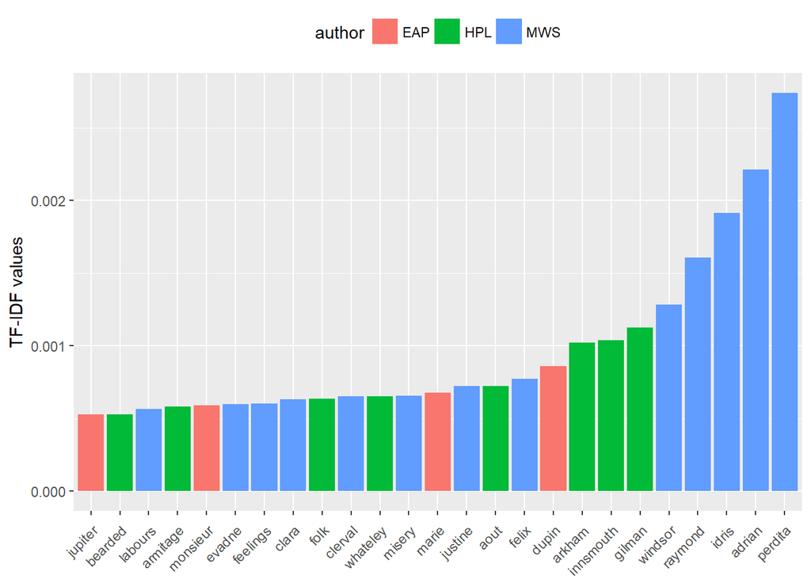

```r
tf_idf    <- arrange(tf_idf, desc(tf_idf))
tf_idf    <- mutate(tf_idf, word = factor(word, levels = rev(unique(word))))

tf_idf_25 <- top_n(tf_idf, 25, tf_idf)
#png("../figs/tf_idf_25.png")
ggplot(tf_idf_25) +
  geom_col(aes(word, tf_idf, fill = author)) +
  labs(x = NULL, y = "TF-IDF values") +
  theme(legend.position = "top", axis.text.x  = element_text(angle=45, hjust=1, vjust=0.9))
```

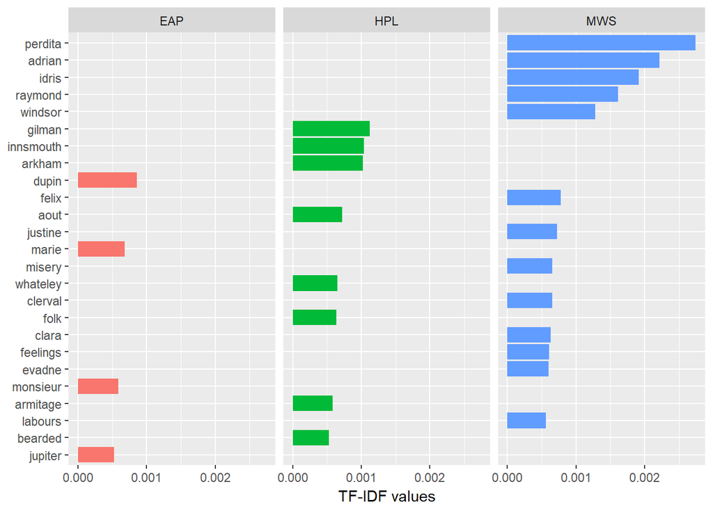

```r
#png("../figs/tf_idf_25sep.png")
ggplot(tf_idf_25) +
  geom_col(aes(word, tf_idf, fill = author)) +
  labs(x = NULL, y = "TF-IDF values") +
  coord_flip() +
  facet_wrap(~ author) +
  theme(legend.position = "none")
```

The first table is the head part of TF-IDF distribution table. and the second one is the tail part of the TF-IDF list. From the distribution histogram, the typical words are usually names or nouns, which are related to different topics and contents different author like to discuss. They can be regarded as signs to recognize who the author is of a certain text.

6. Sentiment Analysis

```r
#library(janeaustenr)
library(dplyr)
library(stringr)
library(tidyr)

samplesentiment <- spk_wrd %>%
  inner_join(get_sentiments("bing")) %>%
  count(author, index = linenumber %/% 50, sentiment) %>%
  spread(sentiment, n, fill = 0) %>%
  mutate(sentiment = positive - negative)
```

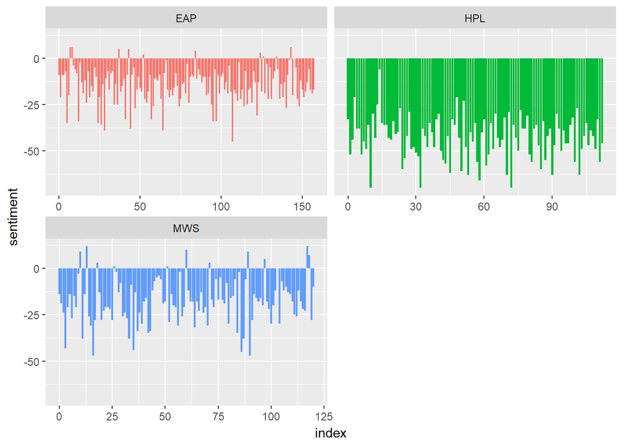

```r
library(ggplot2)
#png("../figs/sentimentbing.png")

ggplot(samplesentiment, aes(index, sentiment, fill = author)) +
  geom_col(show.legend = FALSE) +
  facet_wrap(~author, ncol = 2, scales = "free_x")
```

Here I use Bing et al. as the lexicon to analyse the emotional bias. I use the value of positive - negative as the representative of sentiment, and put every 50 sentences as a group to make analysis. From the graphs above, we can conclude most of the time all of the authors discussed about negative things, especially HPL.

```r
bing_word_counts <- spk_wrd %>%
  inner_join(get_sentiments("bing")) %>%
  count(word, author, sentiment, sort = TRUE) %>%
  ungroup()
bing_word_counts
```

```
## # A tibble: 6,799 x 4
##    word      author sentiment     n
##    <chr>     <fct>  <chr>     <int>
##  1 love      MWS    positive    273
##  2 death     MWS    negative    192
##  3 strange   HPL    negative    169
##  4 fear      MWS    negative    117
##  5 dark      HPL    negative    107
##  6 doubt     EAP    negative    106
##  7 misery    MWS    negative    101
##  8 happiness MWS    positive    100
##  9 death     EAP    negative     99
## 10 fear      HPL    negative     99
## # ... with 6,789 more rows
```

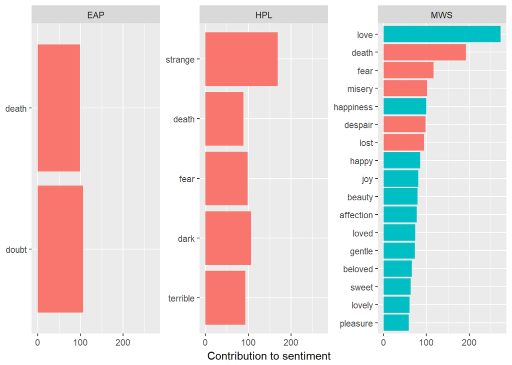

```r
#png("../figs/sentimenttopword.png")
bing_word_counts %>%
  group_by(sentiment) %>%
  top_n(12) %>%
  ungroup() %>%
  mutate(word = reorder(word, n)) %>%
  ggplot(aes(word, n, fill = sentiment)) +
  geom_col(show.legend = FALSE) +
  facet_wrap(~author, scales = "free_y") +
  labs(y = "Contribution to sentiment",
       x = NULL) +
  coord_flip()
```

Here are the distribution of emotional words. The table shows the words, their sentiment categories, and the quantities, and their author. The graph is more straightforward, and it shows the words with sentiment of top 12 frequencies in the whole dataset. We can observe that MWS use most sentimental words, and in contrary, HPL and EAP have a more calm and cold writing style. Besides, MWS prefer to use more warm and positive words, while the other two authors like to use negative words.

```r
afinneap <- spk_eap %>%
  inner_join(get_sentiments("afinn")) %>%
  group_by(index = linenumber %/% 50) %>%
  summarise(sentiment = sum(score)) %>%
  mutate(method = "AFINN")
bing_and_nrceap <- bind_rows(spk_eap %>%
                            inner_join(get_sentiments("bing")) %>%
                            mutate(method = "Bing et al."),
                          spk_eap %>%
                            inner_join(get_sentiments("nrc") %>%
                                         filter(sentiment %in% c("positive",
                                                                 "negative"))) %>%
                            mutate(method = "NRC")) %>%
  count(method, index = linenumber %/% 50, sentiment) %>%
  spread(sentiment, n, fill = 0) %>%
  mutate(sentiment = positive - negative)
```

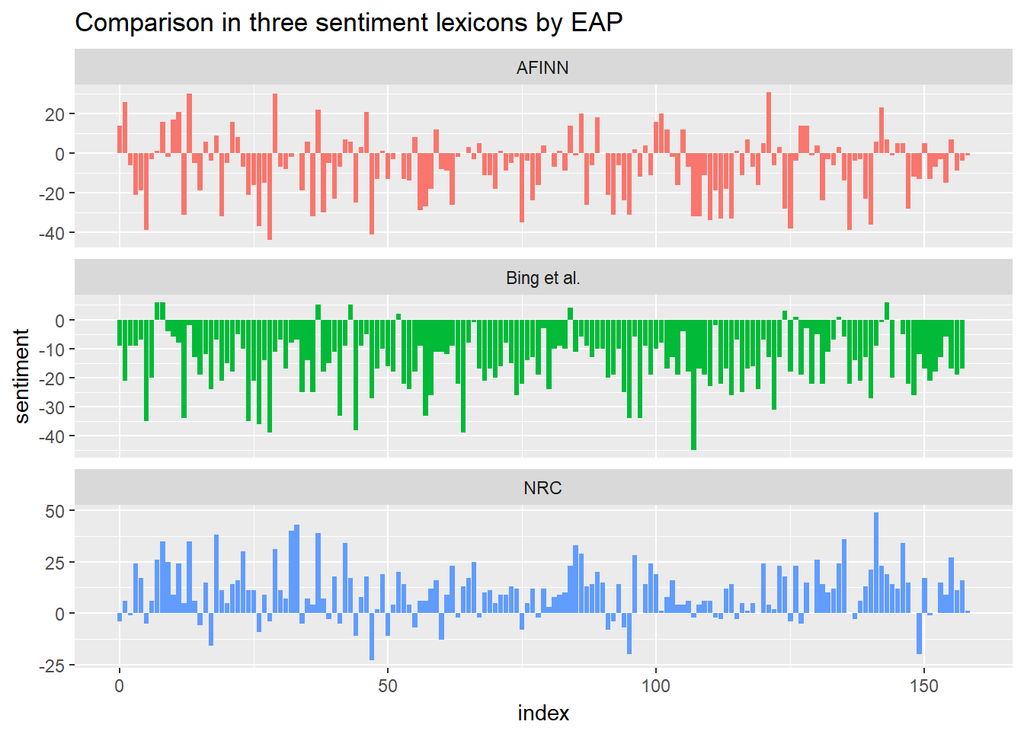

```r
#png("../figs/sentimentcompeap.png")
bind_rows(afinneap,
          bing_and_nrceap) %>%
  ggplot(aes(index, sentiment, fill = method)) +
  geom_col(show.legend = FALSE) +
  facet_wrap(~method, ncol = 1, scales = "free_y") +
  ggtitle("Comparison in three sentiment lexicons by EAP", subtitle = NULL)
```

```r
afinnhpl <- spk_hpl %>%
  inner_join(get_sentiments("afinn")) %>%
  group_by(index = linenumber %/% 50) %>%
  summarise(sentiment = sum(score)) %>%
  mutate(method = "AFINN")
bing_and_nrchpl <- bind_rows(spk_hpl %>%
                            inner_join(get_sentiments("bing")) %>%
                            mutate(method = "Bing et al."),
                          spk_hpl %>%
                            inner_join(get_sentiments("nrc") %>%
                                         filter(sentiment %in% c("positive",
                                                                 "negative"))) %>%
                            mutate(method = "NRC")) %>%
  count(method, index = linenumber %/% 50, sentiment) %>%
  spread(sentiment, n, fill = 0) %>%
  mutate(sentiment = positive - negative)
```

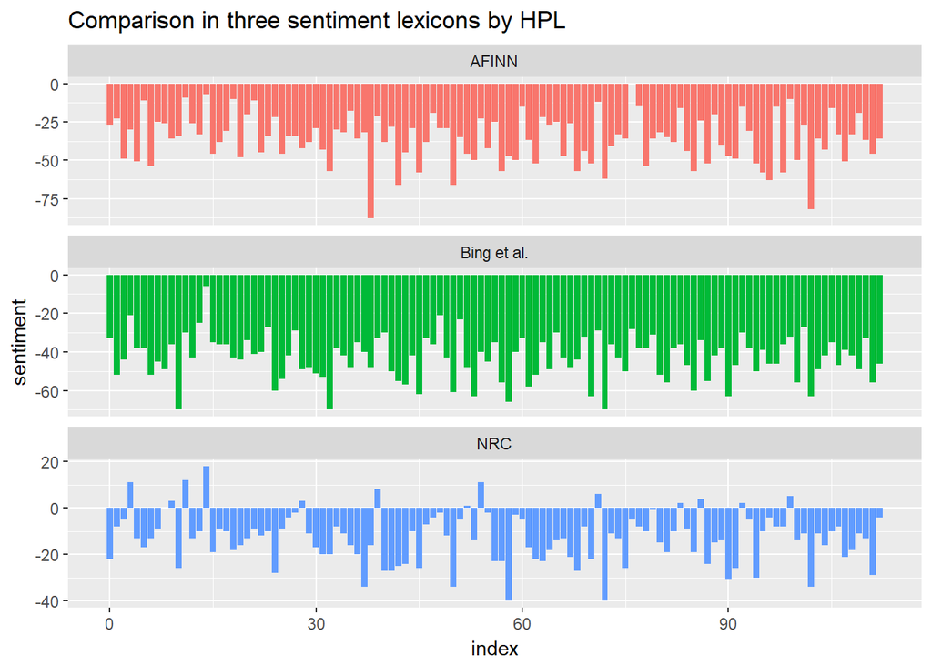

```r
#png("../figs/sentimentcomphpl.png")
bind_rows(afinnhpl,
          bing_and_nrchpl) %>%
  ggplot(aes(index, sentiment, fill = method)) +
  geom_col(show.legend = FALSE) +
  facet_wrap(~method, ncol = 1, scales = "free_y") +
  ggtitle("Comparison in three sentiment lexicons by HPL", subtitle = NULL)
```

```r
afinnmws <- spk_mws %>%
  inner_join(get_sentiments("afinn")) %>%
  group_by(index = linenumber %/% 50) %>%
  summarise(sentiment = sum(score)) %>%
  mutate(method = "AFINN")
```

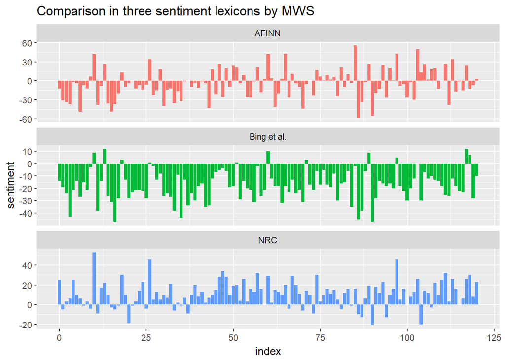

```r
#png("../figs/sentimentcompmws.png")
bing_and_nrcmws <- bind_rows(spk_mws %>%
                            inner_join(get_sentiments("bing")) %>%
                            mutate(method = "Bing et al."),
                          spk_mws %>%
                            inner_join(get_sentiments("nrc") %>%
                                         filter(sentiment %in% c("positive",
                                                                 "negative"))) %>%
                            mutate(method = "NRC")) %>%
  count(method, index = linenumber %/% 50, sentiment) %>%
  spread(sentiment, n, fill = 0) %>%
  mutate(sentiment = positive - negative)
bind_rows(afinnmws,
          bing_and_nrcmws) %>%
  ggplot(aes(index, sentiment, fill = method)) +
  geom_col(show.legend = FALSE) +
  facet_wrap(~method, ncol = 1, scales = "free_y") +
  ggtitle("Comparison in three sentiment lexicons by MWS", subtitle = NULL)
```

```r
get_sentiments("nrc") %>%
     filter(sentiment %in% c("positive",
                             "negative")) %>%
  count(sentiment)
```

```
## # A tibble: 2 x 2
##   sentiment     n
##   <chr>     <int>
## 1 negative   3324
## 2 positive   2312
```

```r
get_sentiments("bing") %>%
  count(sentiment)
```

```
## # A tibble: 2 x 2
##   sentiment     n
##   <chr>     <int>
## 1 negative   4782
## 2 positive   2006
```

7. Relationships between 2-grams

```r
library(dplyr)
library(tidytext)
#library(janeaustenr)

eap_sentence <- filter(spk_byauthor, author == "EAP")
hpl_sentence <- filter(spk_byauthor, author == "HPL")
mws_sentence <- filter(spk_byauthor, author == "MWS")

eap_bigrams <- eap_sentence %>%
  unnest_tokens(bigram, text, token = "ngrams", n = 2)
hpl_bigrams <- hpl_sentence %>%
  unnest_tokens(bigram, text, token = "ngrams", n = 2)
mws_bigrams <- mws_sentence %>%
  unnest_tokens(bigram, text, token = "ngrams", n = 2)
spk_bigrams <- spk_byauthor %>%
  unnest_tokens(bigram, text, token = "ngrams", n = 2)

eap_bigrams %>%
  count(bigram, sort = TRUE)
```

```
## # A tibble: 95,814 x 2
##    bigram       n
##    <chr>    <int>
##  1 of the    2877
##  2 in the    1237
##  3 to the     823
##  4 of a       530
##  5 to be      431
##  6 and the    428
##  7 it was     419
##  8 from the   403
##  9 upon the   399
## 10 it is      362
## # ... with 95,804 more rows
```

```r
hpl_bigrams %>%
  count(bigram, sort = TRUE)
```

```
## # A tibble: 85,367 x 2
##    bigram       n
##    <chr>    <int>
##  1 of the    1487
##  2 in the     901
##  3 and the    503
##  4 to the     490
##  5 on the     428
##  6 from the   350
##  7 it was     348
##  8 i had      287
##  9 at the     277
## 10 of a       277
## # ... with 85,357 more rows
```

```r
mws_bigrams %>%
  count(bigram, sort = TRUE)
```

```
## # A tibble: 82,010 x 2
##    bigram       n
##    <chr>    <int>
##  1 of the    1217
##  2 in the     605
##  3 to the     534
##  4 and the    412
##  5 of my      359
##  6 on the     356
##  7 i was      330
##  8 that i     296
##  9 from the   283
## 10 i had      273
## # ... with 82,000 more rows
```

```r
spk_bigrams %>%
  count(bigram, sort = TRUE)
```

```
## # A tibble: 221,753 x 2
##    bigram       n
##    <chr>    <int>
##  1 of the    5581
##  2 in the    2743
##  3 to the    1847
##  4 and the   1343
##  5 it was    1037
##  6 from the  1036
##  7 on the    1011
##  8 of a       986
##  9 i had      861
## 10 of my      812
## # ... with 221,743 more rows
```

```r
bigrams_separated <- spk_bigrams %>%
  separate(bigram, c("word1", "word2"), sep = " ")

bigrams_filtered <- bigrams_separated %>%
  filter(!word1 %in% stop_words$word) %>%
  filter(!word2 %in% stop_words$word)

# new bigram counts:
bigram_counts <- bigrams_filtered %>%
  count(word1, word2, sort = TRUE)

bigrams_united <- bigrams_filtered %>%
  unite(bigram, word1, word2, sep = " ")

bigram_counts_au <- bigrams_filtered %>%
  group_by(author) %>%
  count(word1, word2, sort = TRUE) %>%
  ungroup
bigram_counts_au
```

```
## # A tibble: 47,540 x 4
##    author word1   word2           n
##    <fct>  <chr>   <chr>       <int>
##  1 MWS    lord    raymond        27
##  2 EAP    ha      ha             22
##  3 MWS    fellow  creatures      22
##  4 EAP    main    compartment    21
##  5 EAP    madame  lalande        20
##  6 EAP    chess   player         18
##  7 HPL    heh     heh            17
##  8 HPL    shunned house          16
##  9 HPL    tempest mountain       14
## 10 MWS    native  country        14
## # ... with 47,530 more rows
```

The first three tables are bigram list of EAP, HPL and MWS, which show bigrams and their frequencies. The fourth table is a summary table of the whole dataset. Form the table, it is clear that all of authors like to use stop words ‘of the’, ‘in the’, ‘to the’ and etc. The last table is the bigram distribution without consideration of stop words. It shows usually MWS uses bigram to mention people, while others tend to use more modal particles like ‘ha ha’.

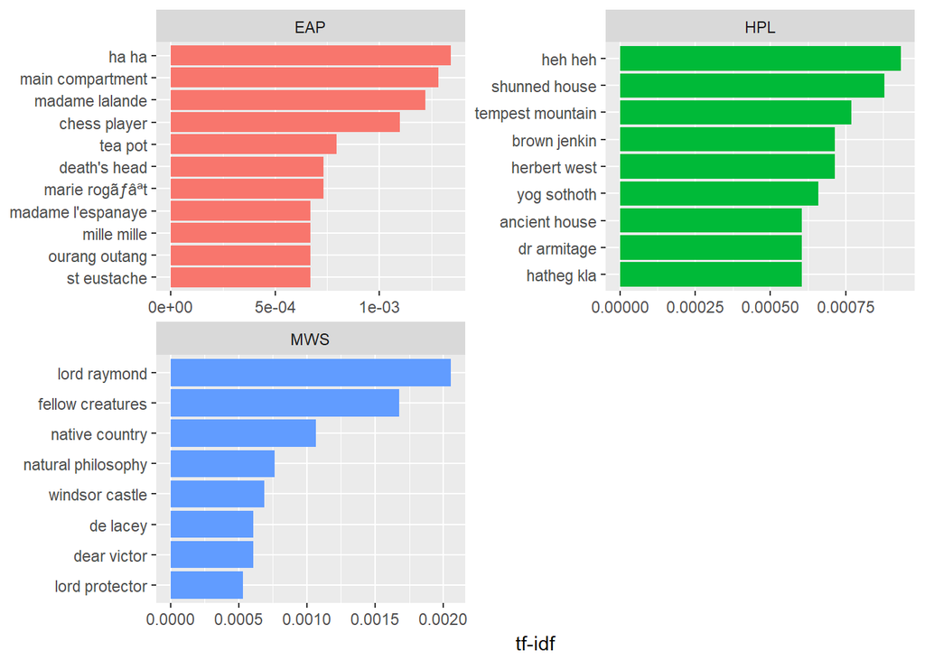

```r
bigram_tf_idf <- bigrams_united %>%
  count(author, bigram) %>%
  bind_tf_idf(bigram, author, n) %>%
  arrange(desc(tf_idf))
#png("../figs/bigramtf.png")
bigram_tf_idf %>%
  mutate(bigram = factor(bigram, levels = rev(unique(bigram)))) %>%
  group_by(author) %>%
  top_n(8) %>%
  ungroup %>%
  ggplot(aes(bigram, tf_idf, fill = author)) +
  geom_col(show.legend = FALSE) +
  labs(x = NULL, y = "tf-idf") +
  facet_wrap(~author, ncol = 2, scales = "free") +
  coord_flip()
```

They are a more straightforward presentation of the last part. Each graph shows the top bigrams each author like to use, and the bigrams also leak some details of their stories.

```r
AFINN <- get_sentiments("afinn")
AFINN
```

```
## # A tibble: 2,476 x 2
##    word       score
##    <chr>      <int>
##  1 abandon       -2
##  2 abandoned     -2
##  3 abandons      -2
##  4 abducted      -2
##  5 abduction     -2
##  6 abductions    -2
##  7 abhor         -3
##  8 abhorred      -3
##  9 abhorrent     -3
## 10 abhors        -3
## # ... with 2,466 more rows
```

```r
negation_words <- c("not", "no", "never", "without")

negated_words <- bigrams_separated %>%
  filter(word1 %in% negation_words) %>%
  inner_join(AFINN, by = c(word2 = "word")) %>%
  count(word1, word2, score, sort = TRUE) %>%
  ungroup()
negated_words
```

```
## # A tibble: 311 x 4
##    word1 word2   score     n
##    <chr> <chr>   <int> <int>
##  1 no    doubt      -1    60
##  2 not   help        2    29
##  3 not   like        2    26
##  4 not   fail       -2    23
##  5 not   wish        1    20
##  6 not   die        -3    15
##  7 never forget     -1     9
##  8 not   pretend    -1     9
##  9 no    good        3     8
## 10 no    hope        2     8
## # ... with 301 more rows
```